# Statistical Learning report

Elisa Ferrero and Andrea Pizzolato

September 2, 2023

# Dataset

The dataset is the nassCDS dataset, from the package ‘DAAG’. It contains data about traffic incidents, recorded from 1997 to 2002, where at least one vehicle was towed and there was harm to people or property. This data is sampled by the NASS (Nationat Automotive Sampling System), mantained by a US government agency, the National Highway Traffic Safety Administration (NHTSA).

```r
library('DAAG')
library('tidyverse')
library('wCorr')
library('MASS')
library('Hmisc')
library('car')
library('WeightedROC')
library('caret')
library('yardstick')
library('glmnet')

set.seed(12321)
data<-nassCDS
head(data)
```

```
##   dvcat  weight  dead airbag seatbelt frontal sex ageOFocc yearacc yearVeh
## 1 25-39  25.069 alive   none   belted       1   f       26    1997    1990
## 2 10-24  25.069 alive airbag   belted       1   f       72    1997    1995
## 3 10-24  32.379 alive   none     none       1   f       69    1997    1988
## 4 25-39 495.444 alive airbag   belted       1   f       53    1997    1995
## 5 25-39  25.069 alive   none   belted       1   f       32    1997    1988
## 6 40-54  25.069 alive   none   belted       1   f       22    1997    1985
##     abcat occRole deploy injSeverity caseid
## 1 unavail  driver      0           3  2:3:1
## 2  deploy  driver      1           1  2:3:2
## 3 unavail  driver      0           4  2:5:1
## 4  deploy  driver      1           1 2:10:1
## 5 unavail  driver      0           3 2:11:1
## 6 unavail  driver      0           3 2:11:2
```

The dataset has dimensions 26217, 15, with 26217 observations and 15 columns. The columns are:

- dvcat: ordered factor containing the estimated impact speed, with levels 1-9 km/h, 10-24, 25-39, 40-54, 55+;
- dead: whether the person is dead or alive;
- weight: observation weight of the entry: this dataset is a summary of a much bigger dataset with ~12 million entries. To model the actual dataset, we have to consider the weight of each observation;
- airbag: factor with levels none and airbag, representing whether the vehicle had an airbag;
- seatbelt: factor with levels none and belted, representing whether the person had their seatbelt on;
- frontal: numeric value, 1 for frontal impact, 0 for not
- sex: factor with levels f and m, for the sex of the person
- ageOFocc: numerical age in years of the occupant
- yearacc: year of the accident
- yearVeh: year of fabrication of the vehicle
- abcat: factor describing whether or not at least one airbag deployed. Levels are deploy, nodeploy and unavail
- occRole: factor describing the position of the occupant: driver or pass
- deploy: numeric vector: 0 if an airbag was unavailable or did not deploy; 1 if one or more bags deployed.
- injSeverity: numeric vector describing gravity of injuries: 0:none, 1:possible injury, 2:no incapacity, 3:incapacity, 4:killed; 5:unknown, 6:prior death
- caseid: id of the case

All in all, we have:

- 3 numerical but not continuous predictors: dvcat, ageOFocc and yearveh;
- 6 binary predictors: airbag, deploy, seatbelt, sex, frontal and occRole;
- injSeverity and dead as possible responses

## A first look at the variables

First, we took a look at the distributions of the variables, and how they’re split with respect to the injuries.

```r
data<-na.omit(data)
data$injSevFactor <- factor(data$injSeverity,levels=c(0,1,2,3,4,5,6),labels=c('none','possible','no incapacity','incapacity','killed','unknown','prior death'))
```

### dvcat

Before creating the plot, we convert dvcat to a numerical variable, converting each range of speeds to its midpoint.

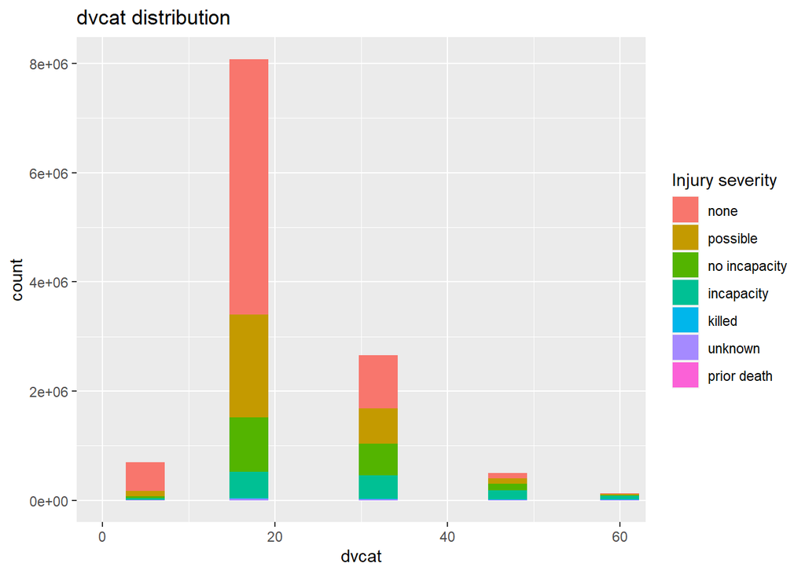

```r
data$dvcat<-as.numeric(data$dvcat)
data$dvcat[data$dvcat==3]=32
data$dvcat[data$dvcat==4]=47
data$dvcat[data$dvcat==5]=60
data$dvcat[data$dvcat==1]=5
data$dvcat[data$dvcat==2]=17
ggplot(data=data)+geom_bar(mapping=aes(x=dvcat,fill=injSevFactor,weight=weight))+
  labs(title='dvcat distribution',fill='Injury severity')+coord_cartesian(xlim = c(0, 60))
```

We also visualize the distribution with a boxplot:

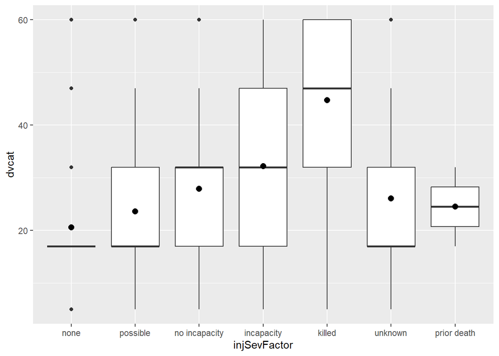

```r
ggplot(data=data,aes(x=injSevFactor, y=dvcat )) +
    geom_boxplot()+stat_summary(fun=mean, geom='point', shape=20, size=4)
```

From these two graphs we can clearly see that the severity of injuries tends to grow as speed increases.

The means of injSeverity, grouping the dataset by dvcat, are:

```
## # A tibble: 5 × 2
##   dvcat mean_injury
##   <dbl>       <dbl>
## 1     5       0.410
## 2    17       0.681
## 3    32       1.21
## 4    47       1.84
## 5    60       2.44
```

### seatbelt

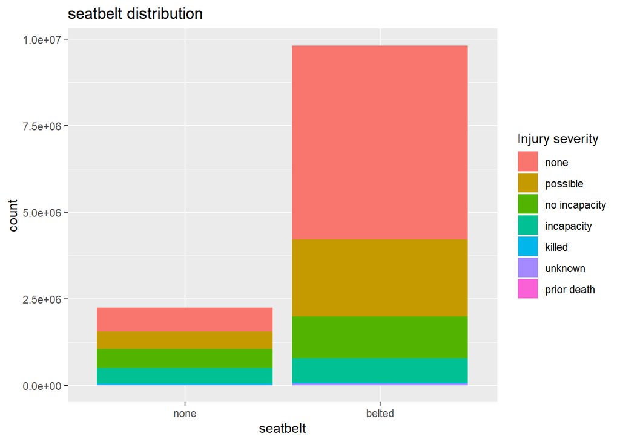

```
## # A tibble: 2 × 2
##   seatbelt mean_injury
##   <fct>          <dbl>
## 1 none           1.41
## 2 belted         0.722
```

So seatbelts do seem to reduce injuries, as expected.

### frontal

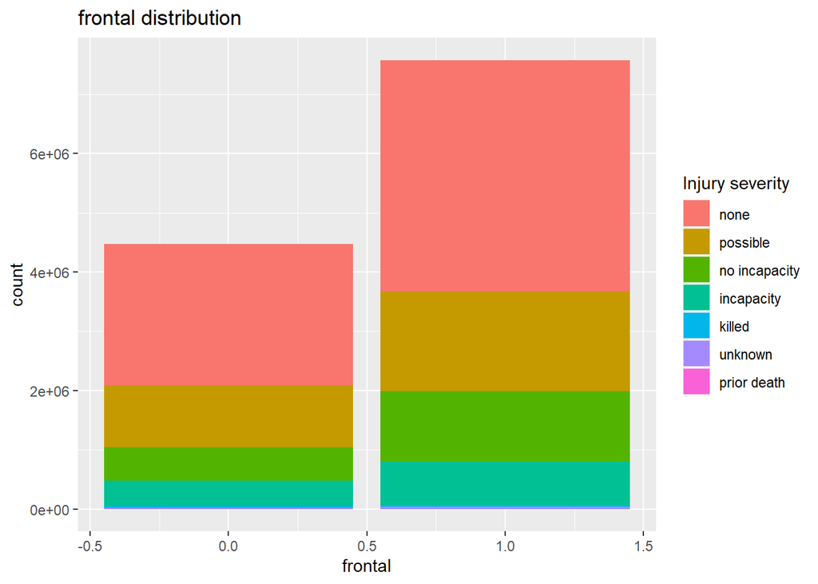

```
## # A tibble: 2 × 2
##   frontal mean_injury
##     <dbl>       <dbl>
## 1       0       0.822
## 2       1       0.865
```

### sex

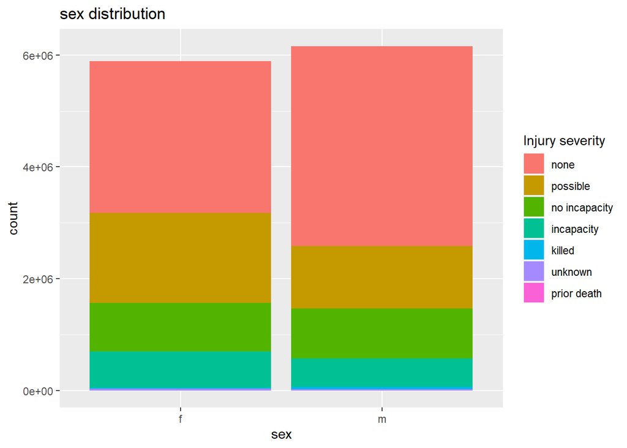

```
## # A tibble: 2 × 2
##   sex   mean_injury
##   <fct>       <dbl>
## 1 f           0.937
## 2 m           0.764
```

We can see that women seem to have worser injuries.

### ageOfocc

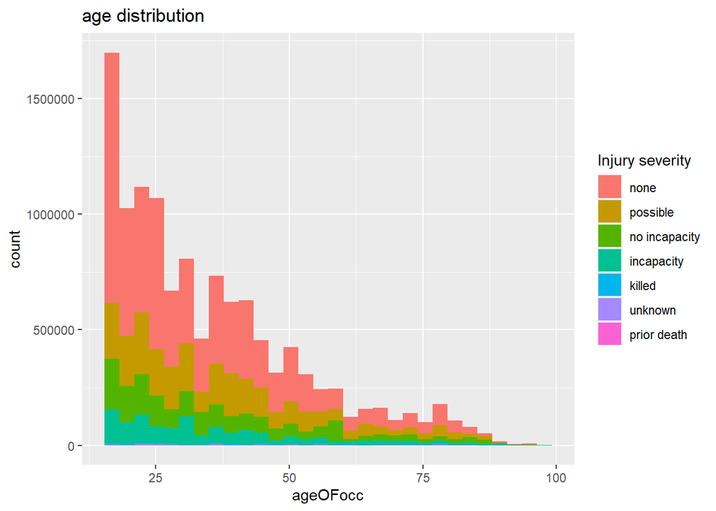

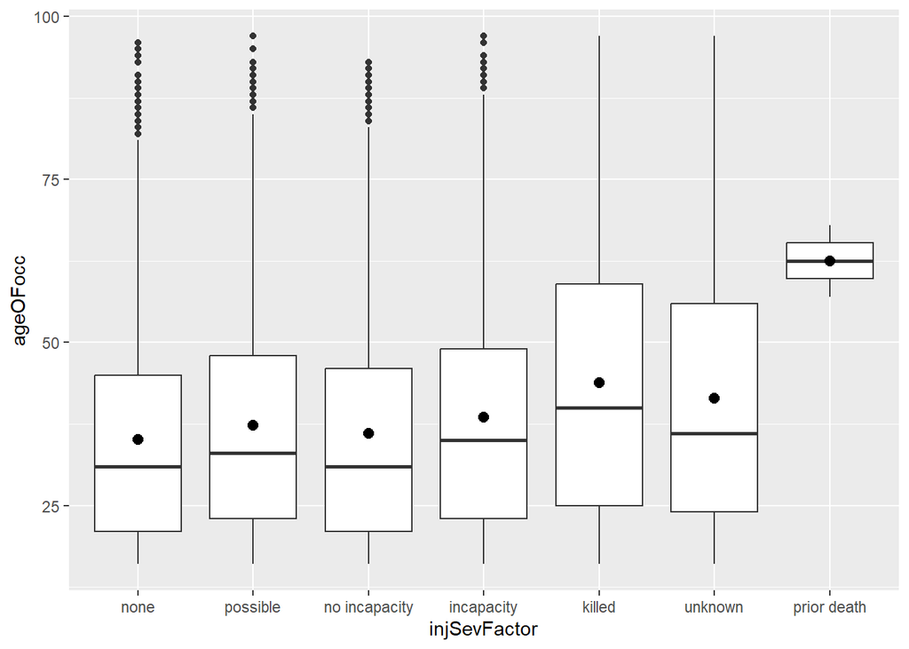

```
## # A tibble: 9 × 2
##   `as.integer(ageOFocc/10)` mean_injury
##                       <int>       <dbl>
## 1                         1       0.707
## 2                         2       0.824
## 3                         3       0.899
## 4                         4       0.829
## 5                         5       0.956
## 6                         6       0.956
## 7                         7       0.983
## 8                         8       1.16
## 9                         9       0.957
```

There seems to be a trend of older people having worse injuries.

### yearVeh

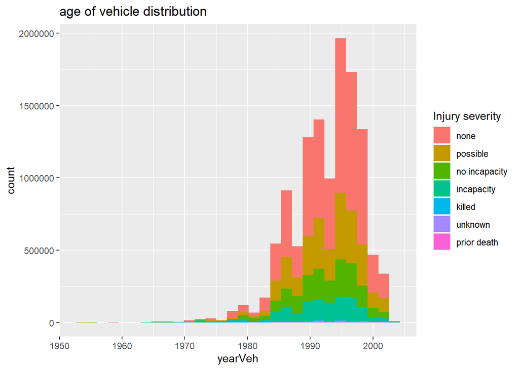

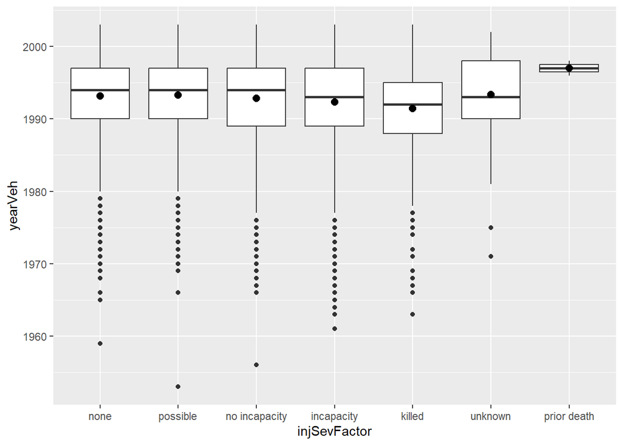

```
## # A tibble: 6 × 2
##   `as.integer(yearVeh/10)` mean_injury
##                      <int>       <dbl>
## 1                      195       0.973
## 2                      196       1.05
## 3                      197       1.28
## 4                      198       0.914
## 5                      199       0.820
## 6                      200       0.786
```

There seems to be a slight tendency towards older vehicles in worse incidents, but nothing major.

### abcat

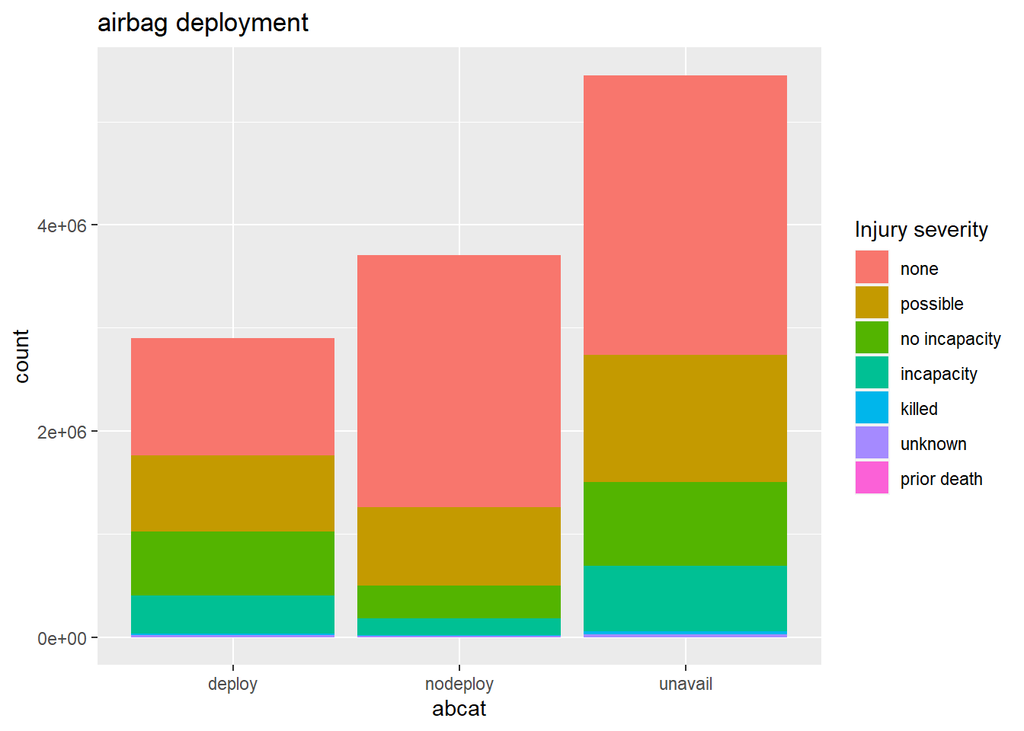

```
## # A tibble: 2 × 2
##   airbag mean_injury
##   <fct>        <dbl>
## 1 none         0.920
## 2 airbag       0.790
```

Vehicles with airbags seem to lead to better outcomes.

### occRole

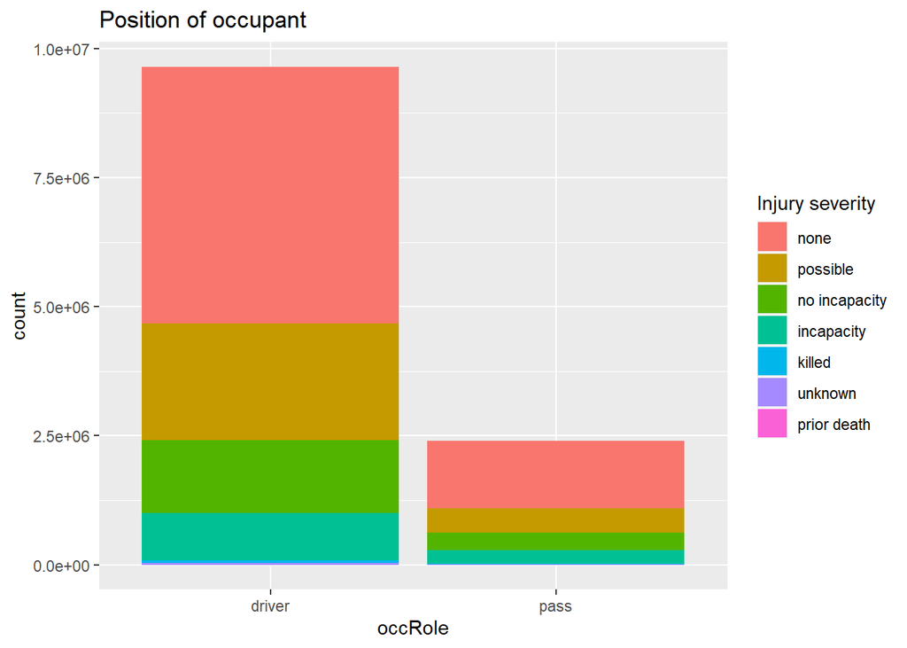

```
## # A tibble: 2 × 2
##   occRole mean_injury
##   <chr>         <dbl>
## 1 driver        0.850
## 2 pass          0.843
```

There doesn’t seem to be a significant difference between outcomes for drivers and passengers.

### Severity of injuries

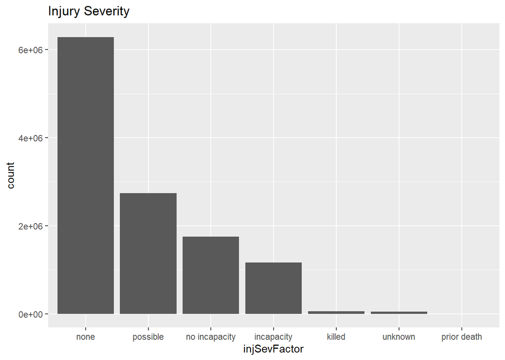

## Questions we can look at

We can use two different responses: dead and injSev.Relative to these variables, we want to look at the following questions:

- Which factors make cars safer?
- There are 2 major safety measures: airbags and seatbelts. How much do these help? Is there synergy between them?
- How do those safety measures interact with other factors, such as the speed of impact or the position and sex of the occupant?
- Are cars built later safer?

## Preprocessing

Before modeling the data, there are a few problems we need to look at:

- There are 3 variables that model the action of airbags. Since they are very strongly correlated, we cannot use more than one as predictor
- We need to convert all the categorical variables to numeric values
- The caseid is useless
- Injury severity 5 (unknown) and 6 (prior death) are useless to us, so we need to delete data with these levels of injury
- We decided to add a feature of the vehicle age, calculated as yearacc-yearVeh
- We need to round the weights of observations

```r
pdata<-data.frame(data)
pdata$vehage<-pdata$yearacc-pdata$yearVeh
pdata$weight<-round(pdata$weight)
pdata<-pdata[pdata$weight>0,]
pdata<-subset(pdata,select=-c(caseid,abcat))
```

### The airbag variables

To sum them up:

- deploy=1 if the airbag deployed (abcat=deploy), 0 if it didn’t (abcat=nodeploy or unavail)
- airbag=1 if the vehicle had an airbag(abcat= deploy or nodeploy), 0 if it didn’t (abcat=unavail)

We decided to use the airbag variable. Deploy might be influenced by things like the speed of impact or other factors of the incident, while airbag depends only on the vehicle.

### Categorical variables

- We set dead=1 when the occupant died
- seatbelt=1 when belted
- sex=1 when f
- occRole=1 when driver

### Deleting incomplete entries

```r
pdata <- pdata[pdata$injSeverity < 5,]
pdata$injSevFactor<-droplevels(pdata$injSevFactor)
head(pdata)
```

```
##   dvcat weight dead airbag seatbelt frontal sex ageOFocc yearacc yearVeh
## 1    32     25    0      0        1       1   1       26    1997    1990
## 2    17     25    0      1        1       1   1       72    1997    1995
## 3    17     32    0      0        0       1   1       69    1997    1988
## 4    32    495    0      1        1       1   1       53    1997    1995
## 5    32     25    0      0        1       1   1       32    1997    1988
## 6    47     25    0      0        1       1   1       22    1997    1985
##   occRole deploy injSeverity injSevFactor vehage
## 1       1      0           3   incapacity      7
## 2       1      1           1     possible      2
## 3       1      0           4       killed      9
## 4       1      1           1     possible      2
## 5       1      0           3   incapacity      9
## 6       1      0           3   incapacity     12
```

## Correlations between variables

Before modeling injSeverity, we took a look at how the variables are related to each other.

To find dependencies between them, we use Cramer’s V:

- Most our variables are categorical, and those who aren’t (ageOFocc and vehage) can easily be split into bins
- Using a chi-square test of independence would be useless, since our dataset is very large, which makes p-values very small.

```r
library('DescTools')
```

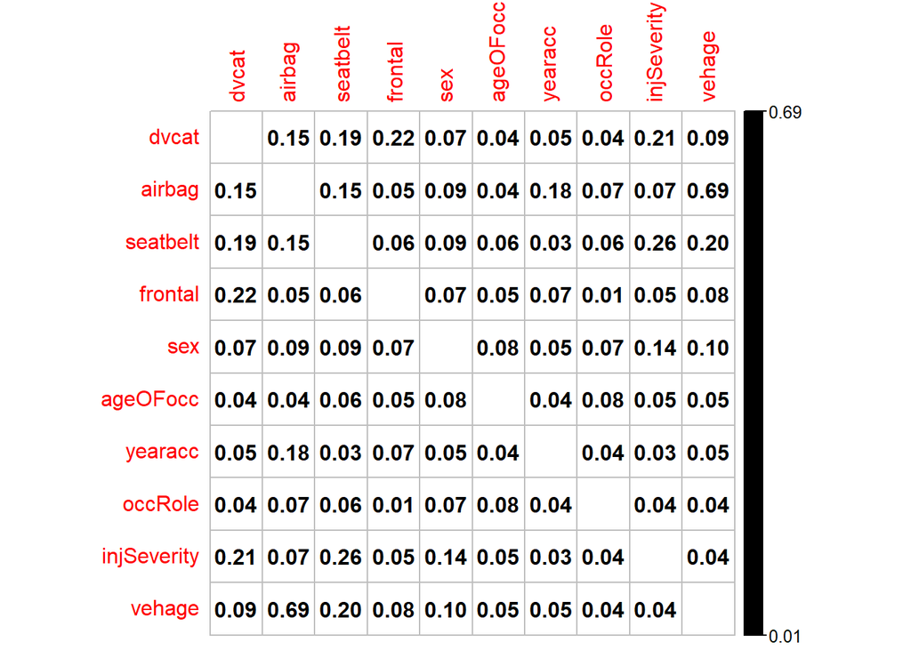

```r
library('corrplot')
library('rcompanion')
corr.data<-subset(pdata,select=-c(dead,weight,injSevFactor,deploy,yearVeh))
corr.data$ageOFocc<-as.integer(corr.data$ageOFocc/15)
corr.data$vehage<-as.integer(corr.data$vehage/7)
weightedV<-function(x,y){
  tab<-xtabs(pdata$weight~x+y)
  cramerV(tab)
}
corrplot(PairApply(corr.data,weightedV,symmetric=TRUE), method = 'number',diag = F,is.corr = F,col='black')
```

in general, we have very weak associations between variables.

- There is a strong association between airbag and vehage
- There is a weak association between dvcat and frontal / airbag / seatbelt
- Injury Severity has some weak associations with dvcat, seatbelt and sex, but not much else
- Weirdly, airbag presence has no association with injury severity

#### Airbag presence and year of construction

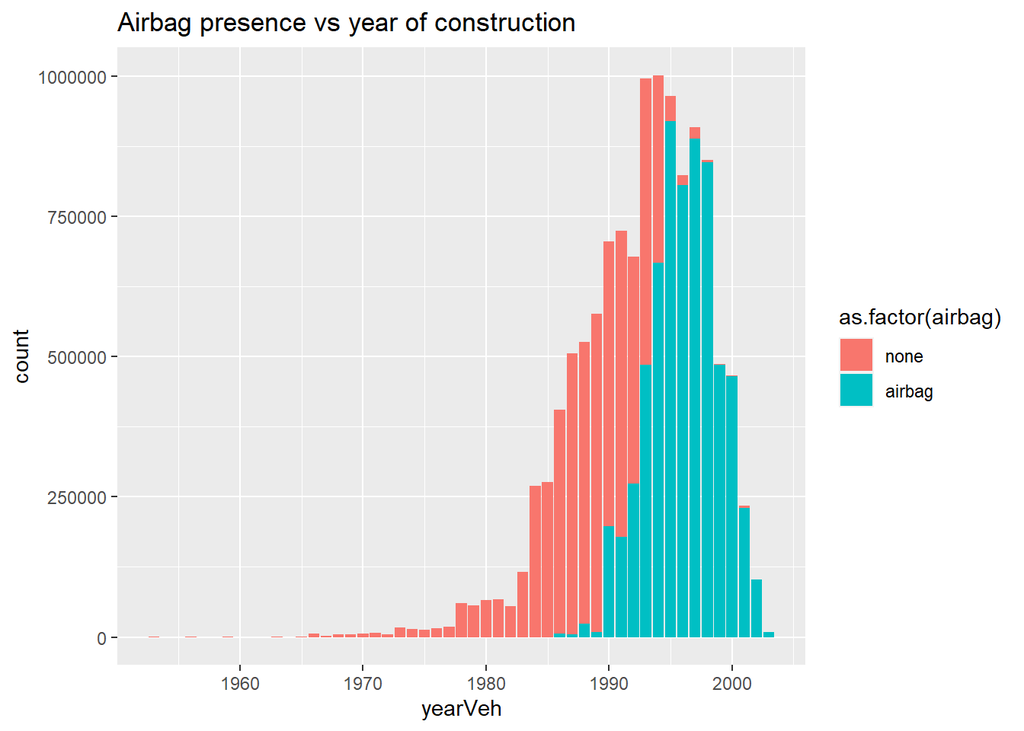

This graph easily explains the correlation: airbags started being included in cars around 1985, and then quickly became a mainstay, until they were included in almost all vehicles in 1995.

### The airbag vs injury severity problem

A possible explanation for the seeming uselessness of airbags could be the following: in many incidents the occupant was not wearing their seatbelt. It could be that not wearing a seatbelt might make the airbag dangerous.

We create a table with the mean injuries depending on airbag and seatbelt:

```r
count.tab<-xtabs(weight~airbag+seatbelt,data=data)
tab<-xtabs(injSeverity*weight~airbag+seatbelt,data=data)
tab/count.tab
```

```
##         seatbelt
## airbag        none    belted
##   none   1.4451376 0.7466525
##   airbag 1.3448483 0.7039665
```

So airbags do seem to help, but very little

To clearly separate the effects of airbags and seatbelts, we create 3 variables that model the 4 possible situations in terms of airbags and seatbelts:

- both airbag and seatbelt
- only the seatbelt
- only the airbag

```r
pdata$beltedab <- pdata$airbag * pdata$seatbelt
pdata$onlyseatbelt=pdata$seatbelt*(1-pdata$airbag)
pdata$onlyairbag=pdata$airbag*(1-pdata$seatbelt)
```

We now model the injury severity as a response of the other variables.

## Modeling injSeverity

### Ordered logistic regression models

Ordered logistic regression is used to model categorical variables where the categories have a natural order, making it a good fit for modeling injSeverity.

Given a categorical variable with (ordered) levels 1,…,J, for $j=1,...,J-1$, we define
$$log\frac{P(Y\leq j)}{P(Y > j)}=logit(P(Y\leq j))$$

And we model it as
$$logit(P(Y\leq j))=\beta_j+\sum_{i=1}^p \eta_i x_i$$

There is an intercept for each cutoff between levels, and it represents the point where we cut the latent variable to create the different levels.

#### Useful functions

We now define some useful R functions:

##### Compute p values of parameters

**polr** models do not include p values by default, so we create a function to compute and print them:

```r
compute_p<-function(m){
  ctable <- coef(summary(m))
  p <- pt(abs(ctable[, "t value"]),m$df.residual, lower.tail = FALSE) * 2
  ctable <- cbind(ctable, "p value" = p)
  print(ctable)
}
```

#### Deviance tests

The deviance test is used to test whether a certain subset of parameters is useful

```r
test_deviance<-function(full.m,reduced.m){
  full_dev<-deviance(full.m)
  reduced_dev<-deviance(reduced.m)
  deg<-reduced.m$df.residual-full.m$df.residual
  print(pchisq(reduced_dev-full_dev,deg,lower.tail=FALSE))
}
```

#### Evaluate model

We use this function to compute the confusion matrix for multi classification models and calculate statistics describing their performance on a test set.

The statistics we’re most interested in are:

- The accuracy
- Cohen’s kappa statistic, a measure of the concordance between the truth and the predictions that takes into account the amount of concordance that’s due to randomness
- The balanced accuracy, the average of the recall obtained on each class

```r
ev.model<-function(m,data){
  preds<-predict(m,data,type='class')
  data$preds<-preds
  conf.mat<-conf_mat(data,injSevFactor,preds,case_weights=weight)
  print(summary(conf.mat))
  autoplot(conf.mat,type='heatmap')
}
```

### Verifying the proportional odds assumption

The ordered logistic regression model assumes that the coefficients that describe the relationship between each division of the categories are the same.

We can verify this assumption graphically by creating a table with the odds of being at least in a certain category, divided by each predictor, and plotting them.

```r
duptimes<-pdata$weight

idx<-rep(1:nrow(pdata),duptimes)

unfolded.data <- pdata[idx,]   # 'Unfolding' the dataset weights


sf <- function(y) {   # Function that computes odds of at least being in a certain category
  c('Y>=1' = qlogis(mean(y >= 1)),
    'Y>=2' = qlogis(mean(y >= 2)),
    'Y>=3' = qlogis(mean(y >= 3)),
    'Y>=4' = qlogis(mean(y >= 4)),
    'Y>=5' = qlogis(mean(y >= 5)))
}

(s <- with(unfolded.data, summary(as.numeric(injSevFactor) ~ onlyseatbelt+onlyairbag+beltedab+dvcat+sex+ageOFocc+occRole+frontal+vehage, fun=sf)))   # Creating the table
```

```
## as.numeric(injSevFactor)      N= 12002009
##
## +------------+-------+--------+----+-----------+----------+----------+---------+
## |            |       |       N|Y>=1|       Y>=2|      Y>=3|      Y>=4|     Y>=5|
## +------------+-------+--------+----+-----------+----------+----------+---------+
## |onlyseatbelt|     No| 7926075| Inf|-0.01177974|-0.9805079|-2.0897791|-5.202334|
## |            |    Yes| 4075934| Inf|-0.25815557|-1.3864796|-2.3650584|-5.684941|
## +------------+-------+--------+----+-----------+----------+----------+---------+
## |  onlyairbag|     No|11124575| Inf|-0.16294394|-1.1854246|-2.2564532|-5.523207|
## |            |    Yes|  877434| Inf| 0.80284627|-0.3008933|-1.4398043|-4.201978|
## +------------+-------+--------+----+-----------+----------+----------+---------+
## |    beltedab|     No| 6304774| Inf| 0.10688740|-0.8781114|-1.8768056|-4.912441|
## |            |    Yes| 5697235| Inf|-0.32095984|-1.4007356|-2.6227348|-6.234158|
## +------------+-------+--------+----+-----------+----------+----------+---------+
## |       dvcat|      5|  689903| Inf|-1.16918996|-2.1152004|-2.8230092|-8.032335|
## |            |     17| 8051862| Inf|-0.32899188|-1.4860385|-2.7420593|-7.287318|
## |            |     32| 2641985| Inf| 0.54199708|-0.4661802|-1.5984298|-5.164403|
## |            |     47|  490765| Inf| 1.48857990| 0.4661723|-0.6101906|-3.428375|
## |            |     60|  127494| Inf| 1.98504415| 1.1643062| 0.5002393|-1.622654|
## +------------+-------+--------+----+-----------+----------+----------+---------+
## |         sex|     No| 6136181| Inf|-0.33323601|-1.1827572|-2.3221599|-5.189302|
## |            |    Yes| 5865828| Inf| 0.15138322|-1.0346314|-2.0405152|-5.530646|
## +------------+-------+--------+----+-----------+----------+----------+---------+
## |    ageOFocc|[16,22)| 3194770| Inf|-0.32840064|-1.1369198|-2.1756708|-5.942592|
## |            |[22,32)| 2921510| Inf|-0.11200154|-1.1718362|-2.1368407|-5.585056|
## |            |[32,46)| 2999372| Inf|-0.02938960|-1.1503984|-2.2355307|-5.403133|
## |            |[46,97]| 2886357| Inf| 0.10926556|-0.9773896|-2.1589078|-4.762696|
## +------------+-------+--------+----+-----------+----------+----------+---------+
## |     occRole|     No| 2393382| Inf|-0.18617951|-1.0786817|-2.0903955|-5.260332|
## |            |    Yes| 9608627| Inf|-0.07241137|-1.1166010|-2.1990468|-5.363176|
## +------------+-------+--------+----+-----------+----------+----------+---------+
## |     frontal|     No| 4456157| Inf|-0.13870586|-1.2138773|-2.1731924|-5.011146|
## |            |    Yes| 7545852| Inf|-0.06929491|-1.0495696|-2.1786496|-5.604151|
## +------------+-------+--------+----+-----------+----------+----------+---------+
## |      vehage|[-1, 4)| 3454303| Inf|-0.26451312|-1.3498737|-2.3551410|-5.612098|
## |            |[ 4, 7)| 2697243| Inf|-0.02367788|-1.0479450|-2.2873865|-5.499831|
## |            |[ 7,11)| 3132957| Inf|-0.14611843|-1.1387248|-2.1538151|-5.295025|
## |            |[11,49]| 2717506| Inf| 0.10661914|-0.8638328|-1.9151564|-5.011012|
## +------------+-------+--------+----+-----------+----------+----------+---------+
## |     Overall|       |12002009| Inf|-0.09503774|-1.1089816|-2.1766207|-5.341814|
## +------------+-------+--------+----+-----------+----------+----------+---------+
```

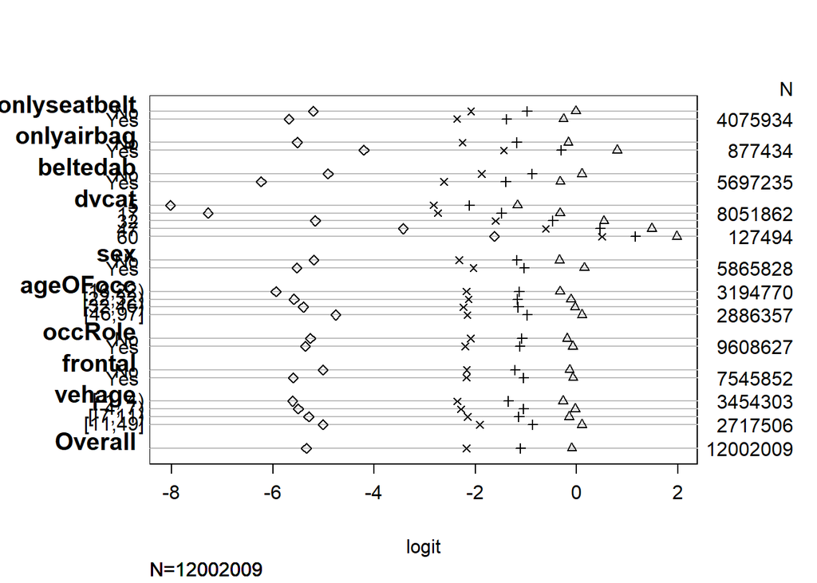

```r
plot(s, which=1:5, pch=1:5, xlab='logit', main=' ',xlim=range(s[,3:6]))
```

For the equal slope assumption to be valid, for each variable, the gaps between the symbols should be constant.

We can see that this is mostly true, except for the symbols representing the odds of $y\geq 5$, that is to say, the odds of death.

```r
library('caTools')
sample <- sample.split(pdata$weight, SplitRatio = 0.7)
train.data  <- subset(pdata, sample == TRUE)
test.data   <- subset(pdata, sample == FALSE)
```

### Full model

First, we fit a model using all predictors:

```r
m<-polr(injSevFactor~onlyseatbelt+onlyairbag+beltedab+dvcat+sex+ageOFocc+occRole+frontal+vehage,data=train.data)
fullord.m<-polr(injSevFactor~onlyseatbelt+onlyairbag+beltedab+dvcat+sex+ageOFocc+occRole+frontal+vehage,data=train.data,weights=weight,Hess=TRUE,start=c(m$coefficients,m$zeta))
```

We now evaluate the model on the test set:

```r
ev.model(fullord.m,test.data)
```

```
## # A tibble: 13 × 3
##    .metric              .estimator .estimate
##    <chr>                <chr>          <dbl>
##  1 accuracy             multiclass    0.508
##  2 kap                  multiclass    0.0902
##  3 sens                 macro         0.242
##  4 spec                 macro         0.817
##  5 ppv                  macro        NA
##  6 npv                  macro         0.861
##  7 mcc                  multiclass    0.126
##  8 j_index              macro         0.0597
##  9 bal_accuracy         macro         0.530
## 10 detection_prevalence macro         0.2
## 11 precision            macro         0.317
## 12 recall               macro         0.242
## 13 f_meas               macro         0.266
```

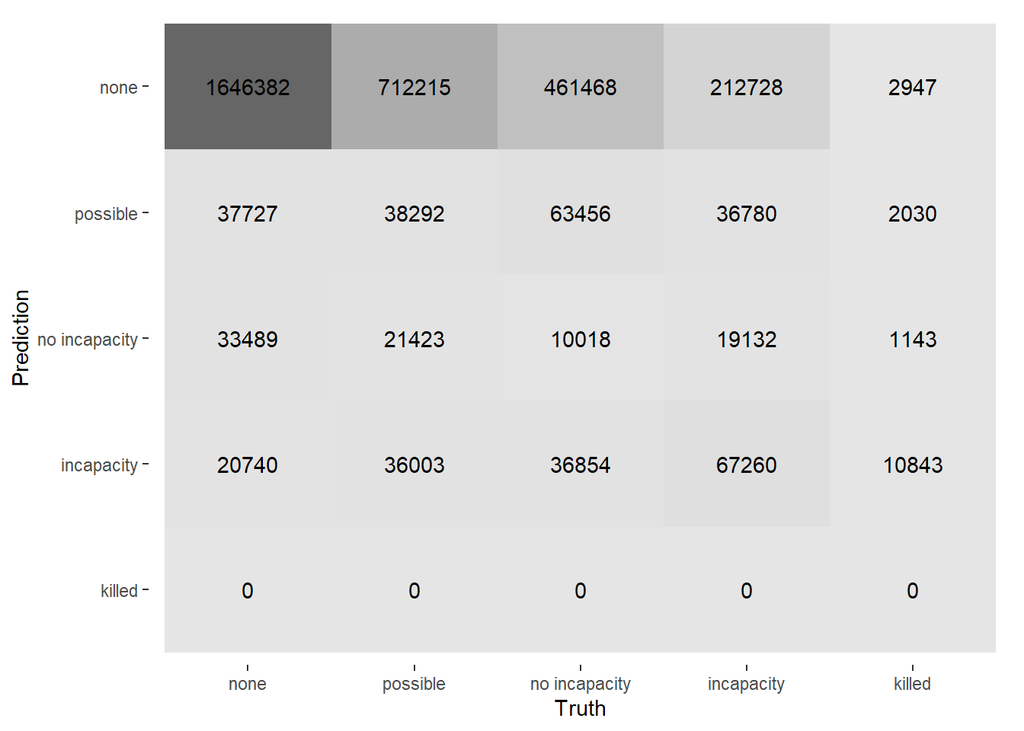

- This model is incapable of predicting the ‘killed’ level!
- The fit is very bad. It grossly overpredicts ‘none’.

To try to solve this problem, we add complexity to the model by also modeling interactions between predictors.

### Best subset model

We now search for the best subset using the AIC.

```r
sample <- sample.split(train.data$weight, SplitRatio = 0.7)
train.tr  <- subset(pdata, sample == TRUE)
train.v   <- subset(pdata, sample == FALSE)
```

We use the stepAIC function, using $k=ln(N)$ (we use the BIC)

```r
empty.m<-polr(injSevFactor~+1,data=train.tr,weights=weight)
stepAIC(empty.m,scope=injSevFactor~onlyseatbelt+onlyairbag+beltedab+dvcat+sex+ageOFocc+occRole+frontal+vehage,direction='forward',k=log(sum(train.tr$weight)))
```

```
## Start:  AIC=20720947
## injSevFactor ~ +1
##
##                Df      AIC
## + dvcat         1 19781998
## + beltedab      1 20573620
## + onlyairbag    1 20580251
## + sex           1 20626748
## + vehage        1 20649077
## + ageOFocc      1 20665943
## + onlyseatbelt  1 20678549
## + frontal       1 20715031
## + occRole       1 20718858
## <none>            20720947
##
## Step:  AIC=19781998
## injSevFactor ~ dvcat
##
##                Df      AIC
## + sex           1 19628626
## + onlyairbag    1 19668134
## + ageOFocc      1 19707974
## + onlyseatbelt  1 19718169
## + beltedab      1 19722711
## + vehage        1 19755314
## + frontal       1 19776630
## + occRole       1 19781574
## <none>            19781998
##
## Step:  AIC=19628626
## injSevFactor ~ dvcat + sex
##
##                Df      AIC
## + onlyairbag    1 19508084
## + beltedab      1 19548303
## + ageOFocc      1 19567479
## + onlyseatbelt  1 19571038
## + vehage        1 19589084
## + frontal       1 19626449
## + occRole       1 19626849
```

[output cut: 50 more lines]

```
## + occRole  1 19096261
## + frontal  1 19097858
## <none>       19101726
##
## Step:  AIC=19096261
## injSevFactor ~ dvcat + sex + onlyairbag + vehage + onlyseatbelt +
##     beltedab + ageOFocc + occRole
##
##           Df      AIC
## + frontal  1 19092512
## <none>       19096261
##
## Step:  AIC=19092512
## injSevFactor ~ dvcat + sex + onlyairbag + vehage + onlyseatbelt +
##     beltedab + ageOFocc + occRole + frontal
```

```
## Call:
## polr(formula = injSevFactor ~ dvcat + sex + onlyairbag + vehage +
##     onlyseatbelt + beltedab + ageOFocc + occRole + frontal, data = train.tr,
##     weights = weight)
##
## Coefficients:
##        dvcat          sex   onlyairbag       vehage onlyseatbelt     beltedab
##   0.06490049   0.59233566   0.05930138   0.01680358  -1.15257988  -1.05774398
##     ageOFocc      occRole      frontal
##   0.01141235   0.12273193  -0.08648094
##
## Intercepts:
##            none|possible   possible|no incapacity no incapacity|incapacity
##                 1.442393                 2.642932                 3.859294
##        incapacity|killed
##                 7.152993
##
## Residual Deviance: 19092304.27
## AIC: 19092330.27
```

The predictors get added in order dvcat , sex , onlyairbag , vehage , onlyseatbelt , beltedab , ageOFocc , occRole , frontal.

Now we fit each partial model and test them on the validation set.

```r
m1<-polr(injSevFactor~dvcat,data=train.tr,weights=weight)
m2<-polr(injSevFactor~dvcat+sex,data=train.tr,weights=weight)
m3<-polr(injSevFactor~dvcat+sex+onlyairbag,data=train.tr,weights=weight)
m4<-polr(injSevFactor~dvcat+sex+onlyairbag+vehage,data=train.tr,weights=weight)
m5<-polr(injSevFactor~dvcat+sex+onlyairbag+vehage+onlyseatbelt,data=train.tr,weights=weight)
m6<-polr(injSevFactor~dvcat+sex+onlyairbag+vehage+onlyseatbelt+beltedab,data=train.tr,weights=weight)
m7<-polr(injSevFactor~dvcat+sex+onlyairbag+vehage+onlyseatbelt+beltedab+ageOFocc,data=train.tr,weights=weight)
m8<-polr(injSevFactor~dvcat+sex+onlyairbag+vehage+onlyseatbelt+beltedab+ageOFocc+occRole,data=train.tr,weights=weight)
m9<-polr(injSevFactor~dvcat+sex+onlyairbag+vehage+onlyseatbelt+beltedab+ageOFocc+occRole+frontal,data=train.tr,weights=weight)
```

```r
for(m in list(m1,m2,m3,m4,m5,m6,m7,m8,m9)){
preds <- predict(m,train.v,type='class')
newx<-data.frame(preds=preds,target=train.v$injSevFactor,weights=train.v$weight)
conf.mat<-conf_mat(newx,target,preds,case_weights=weights)
print(summary(conf.mat))}
```

```
## # A tibble: 13 × 3
##    .metric              .estimator .estimate
##    <chr>                <chr>          <dbl>
##  1 accuracy             multiclass    0.517
##  2 kap                  multiclass    0.0653
##  3 sens                 macro         0.233
##  4 spec                 macro         0.811
##  5 ppv                  macro        NA
##  6 npv                  macro         0.873
##  7 mcc                  multiclass    0.126
##  8 j_index              macro         0.0442
##  9 bal_accuracy         macro         0.522
## 10 detection_prevalence macro         0.2
## 11 precision            macro         0.435
## 12 recall               macro         0.233
## 13 f_meas               macro         0.463
```

```
## # A tibble: 13 × 3
##    .metric              .estimator .estimate
##    <chr>                <chr>          <dbl>
##  1 accuracy             multiclass    0.517
##  2 kap                  multiclass    0.0653
##  3 sens                 macro         0.233
##  4 spec                 macro         0.811
##  5 ppv                  macro        NA
##  6 npv                  macro         0.873
##  7 mcc                  multiclass    0.126
##  8 j_index              macro         0.0442
##  9 bal_accuracy         macro         0.522
## 10 detection_prevalence macro         0.2
## 11 precision            macro         0.435
## 12 recall               macro         0.233
## 13 f_meas               macro         0.463
```

```
## # A tibble: 13 × 3
##    .metric              .estimator .estimate
##    <chr>                <chr>          <dbl>
##  1 accuracy             multiclass    0.520
##  2 kap                  multiclass    0.0836
##  3 sens                 macro         0.236
##  4 spec                 macro         0.815
##  5 ppv                  macro        NA
##  6 npv                  macro         0.878
##  7 mcc                  multiclass    0.139
##  8 j_index              macro         0.0508
##  9 bal_accuracy         macro         0.525
## 10 detection_prevalence macro         0.2
## 11 precision            macro         0.387
## 12 recall               macro         0.236
## 13 f_meas               macro         0.332
```

```
## # A tibble: 13 × 3
##    .metric              .estimator .estimate
##    <chr>                <chr>          <dbl>
##  1 accuracy             multiclass    0.513
##  2 kap                  multiclass    0.0870
##  3 sens                 macro         0.237
##  4 spec                 macro         0.817
##  5 ppv                  macro        NA
##  6 npv                  macro         0.863
##  7 mcc                  multiclass    0.125
##  8 j_index              macro         0.0531
##  9 bal_accuracy         macro         0.527
## 10 detection_prevalence macro         0.2
## 11 precision            macro         0.316
## 12 recall               macro         0.237
## 13 f_meas               macro         0.257
```

```
## # A tibble: 13 × 3
##    .metric              .estimator .estimate
##    <chr>                <chr>          <dbl>
##  1 accuracy             multiclass    0.517
##  2 kap                  multiclass    0.0987
##  3 sens                 macro         0.245
##  4 spec                 macro         0.819
##  5 ppv                  macro        NA
##  6 npv                  macro         0.865
##  7 mcc                  multiclass    0.139
##  8 j_index              macro         0.0639
##  9 bal_accuracy         macro         0.532
## 10 detection_prevalence macro         0.2
## 11 precision            macro         0.327
## 12 recall               macro         0.245
## 13 f_meas               macro         0.271
```

```
## # A tibble: 13 × 3
##    .metric              .estimator .estimate
##    <chr>                <chr>          <dbl>
##  1 accuracy             multiclass    0.528
##  2 kap                  multiclass    0.121
##  3 sens                 macro         0.258
##  4 spec                 macro         0.822
##  5 ppv                  macro        NA
##  6 npv                  macro         0.871
##  7 mcc                  multiclass    0.171
##  8 j_index              macro         0.0802
##  9 bal_accuracy         macro         0.540
## 10 detection_prevalence macro         0.2
## 11 precision            macro         0.388
## 12 recall               macro         0.258
## 13 f_meas               macro         0.291
```

```
## # A tibble: 13 × 3
##    .metric              .estimator .estimate
##    <chr>                <chr>          <dbl>
##  1 accuracy             multiclass    0.526
##  2 kap                  multiclass    0.127
##  3 sens                 macro         0.259
##  4 spec                 macro         0.824
##  5 ppv                  macro        NA
##  6 npv                  macro         0.868
##  7 mcc                  multiclass    0.168
##  8 j_index              macro         0.0822
##  9 bal_accuracy         macro         0.541
## 10 detection_prevalence macro         0.2
## 11 precision            macro         0.374
## 12 recall               macro         0.259
## 13 f_meas               macro         0.297
```

```
## # A tibble: 13 × 3
##    .metric              .estimator .estimate
##    <chr>                <chr>          <dbl>
##  1 accuracy             multiclass    0.524
##  2 kap                  multiclass    0.121
##  3 sens                 macro         0.257
##  4 spec                 macro         0.822
##  5 ppv                  macro        NA
##  6 npv                  macro         0.866
##  7 mcc                  multiclass    0.163
##  8 j_index              macro         0.0797
##  9 bal_accuracy         macro         0.540
## 10 detection_prevalence macro         0.2
## 11 precision            macro         0.373
## 12 recall               macro         0.257
## 13 f_meas               macro         0.294
```

```
## # A tibble: 13 × 3
##    .metric              .estimator .estimate
##    <chr>                <chr>          <dbl>
##  1 accuracy             multiclass    0.529
##  2 kap                  multiclass    0.131
##  3 sens                 macro         0.261
##  4 spec                 macro         0.824
##  5 ppv                  macro        NA
##  6 npv                  macro         0.871
##  7 mcc                  multiclass    0.177
##  8 j_index              macro         0.0854
##  9 bal_accuracy         macro         0.543
## 10 detection_prevalence macro         0.2
## 11 precision            macro         0.394
## 12 recall               macro         0.261
## 13 f_meas               macro         0.301
```

We can see that the best model by this criterion is the one with all predictors.

### Adding interactions

There are 36 possible interactions between the predictors. To narrow them and make the fitting easier, we look at the following possible interactions:

- between dvcat and onlyairbag/onlyseatbelt/beltedab: do these safety measures work better/worse at higher speeds?
- between sex and onlyairbag/onlyseatbelt/beltedab: do they work better for men or women?
- between frontal and onlyairbag/onlyseatbelt/beltedab: do they help more in frontal impacts?

### sex

```r
sex.m<-polr(injSevFactor~sex*(onlyseatbelt+onlyairbag+beltedab)+dvcat+occRole+frontal+ageOFocc+vehage,data=train.data,weights=weight,Hess=TRUE)
sex.m$coefficients
```

```
##              sex     onlyseatbelt       onlyairbag         beltedab
##      0.101814117     -1.466093929     -0.008872227     -1.200569700
##            dvcat          occRole          frontal         ageOFocc
##      0.066593175      0.021710862     -0.074238787      0.011568524
##           vehage sex:onlyseatbelt   sex:onlyairbag     sex:beltedab
##      0.013156357      0.796791528      0.301691401      0.355324128
```

Sex does seem to interact with safety measures: it seems that they work worse for women.

### dvcat

```r
dvcat.m<-polr(injSevFactor~dvcat*(onlyseatbelt+onlyairbag+beltedab)+sex+occRole+frontal+ageOFocc+vehage,data=train.data,weights=weight,Hess=TRUE)
dvcat.m$coefficients
```

```
##              dvcat       onlyseatbelt         onlyairbag           beltedab
##         0.08417544        -0.41589695         0.45530029        -0.66762255
##                sex            occRole            frontal           ageOFocc
##         0.55749371         0.01306833        -0.06986892         0.01159877
##             vehage dvcat:onlyseatbelt   dvcat:onlyairbag     dvcat:beltedab
##         0.01150072        -0.02836325        -0.01375148        -0.01624712
```

dvcat seems to have interactions with beltedab/onlyairbag/onlyeatbelt: they seem to become more important at higher speeds. In particular, at low speeds having only an airbag is dangerous.

### frontal

```r
frontal.m<-polr(injSevFactor~frontal*(onlyseatbelt+onlyairbag+beltedab)+sex+dvcat+occRole+ageOFocc+vehage,data=train.data,weights=weight,Hess=TRUE)
frontal.m$coefficients
```

```
##              frontal         onlyseatbelt           onlyairbag
##          0.291653473         -0.691399951          0.198446626
##             beltedab                  sex                dvcat
##         -0.853702120          0.554363507          0.067090701
##              occRole             ageOFocc               vehage
##          0.009352731          0.011765857          0.012444010
## frontal:onlyseatbelt   frontal:onlyairbag     frontal:beltedab
##         -0.625901795         -0.127933442         -0.319348017
```

Frontal seems to have interactions with onlyseatbelt/onlyairbag/beltedab: they seem to work better in frontal impacts

### Putting the interactions together

```r
m<-polr(injSevFactor~(dvcat+sex+frontal)*(onlyseatbelt+onlyairbag+beltedab)+occRole+vehage+ageOFocc,data=train.data)

int_ord.m<-polr(injSevFactor~(dvcat+sex+frontal)*(onlyseatbelt+onlyairbag+beltedab)+occRole+vehage+ageOFocc,data=train.data,weights=weight,Hess=TRUE,start=c(m$coefficients,m$zeta))
```

```r
ev.model(int_ord.m,test.data)
```

```
## # A tibble: 13 × 3
##    .metric              .estimator .estimate
##    <chr>                <chr>          <dbl>
##  1 accuracy             multiclass    0.510
##  2 kap                  multiclass    0.0915
##  3 sens                 macro         0.244
##  4 spec                 macro         0.817
##  5 ppv                  macro        NA
##  6 npv                  macro         0.863
##  7 mcc                  multiclass    0.133
##  8 j_index              macro         0.0612
##  9 bal_accuracy         macro         0.531
## 10 detection_prevalence macro         0.2
## 11 precision            macro         0.333
## 12 recall               macro         0.244
## 13 f_meas               macro         0.267
```

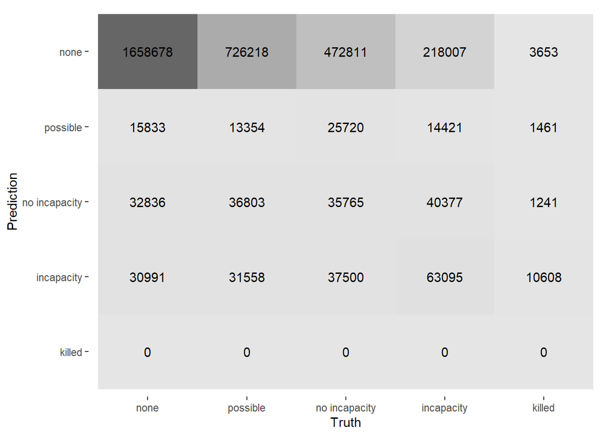

The model is still incapable of predicting ‘killed’, and its performance hasn’t improved significantly.

We also perform a deviance test to see if the interactions have an effect:

```r
test_deviance(int_ord.m,fullord.m)
```

```
## [1] 0
```

## Multinomial logistic regression

We now try a multinomial logistic regression model.

By doing this, we gain the ability to use different coefficients for the relationships between different classes, but we lose the information that the target variable’s levels are ordered.

### Full model

```r
library('nnet')

mult.m<-multinom(injSevFactor~onlyseatbelt+onlyairbag+beltedab+dvcat+sex+ageOFocc+occRole+frontal+vehage,data=train.data,weights=weight,Hess=TRUE)
```

Let’s look at the confusion matrix:

```r
ev.model(mult.m,test.data)
```

```
## # A tibble: 13 × 3
##    .metric              .estimator .estimate
##    <chr>                <chr>          <dbl>
##  1 accuracy             multiclass    0.508
##  2 kap                  multiclass    0.100
##  3 sens                 macro         0.253
##  4 spec                 macro         0.819
##  5 ppv                  macro         0.349
##  6 npv                  macro         0.854
##  7 mcc                  multiclass    0.132
##  8 j_index              macro         0.0716
##  9 bal_accuracy         macro         0.536
## 10 detection_prevalence macro         0.2
## 11 precision            macro         0.349
## 12 recall               macro         0.253
## 13 f_meas               macro         0.239
```

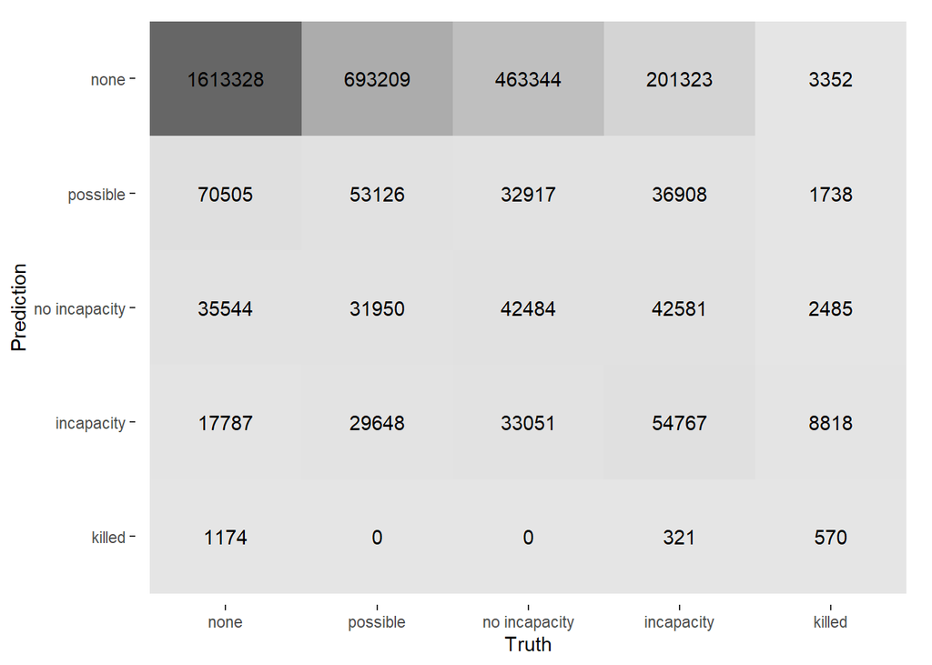

The multinomial model is able to predict all levels, but it still has a very bad performance.

### Subset selection with Lasso

We use lasso regression perform variable selection:

```r
train.x<-as.matrix(subset(train.data,select=-c(weight,dead,airbag,seatbelt,yearacc,yearVeh,deploy,injSeverity,injSevFactor)))
train.y<-train.data$injSevFactor
test.x<-as.matrix(subset(test.data,select=-c(weight,dead,airbag,seatbelt,yearacc,yearVeh,deploy,injSeverity,injSevFactor)))
test.y<-test.data$injSevFactor
```

We train the model:

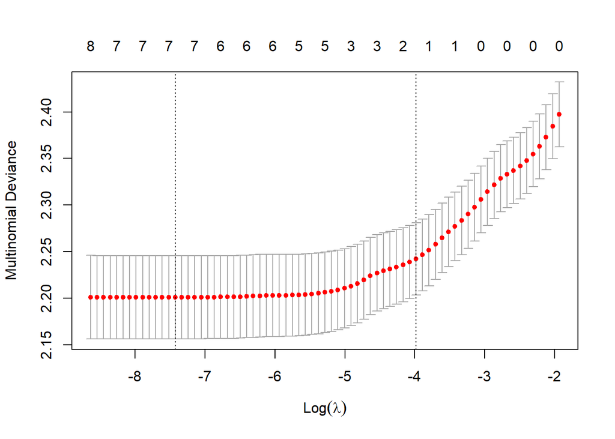

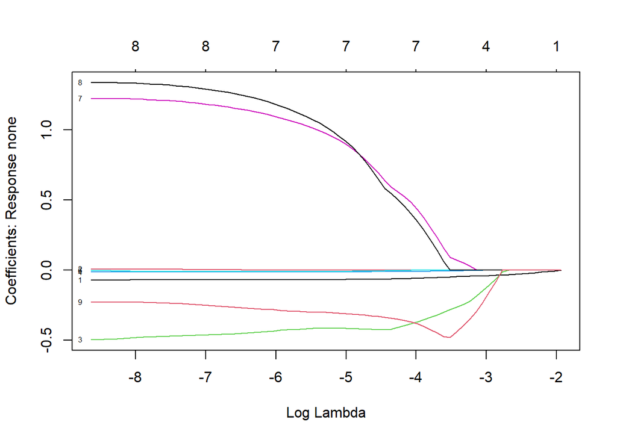

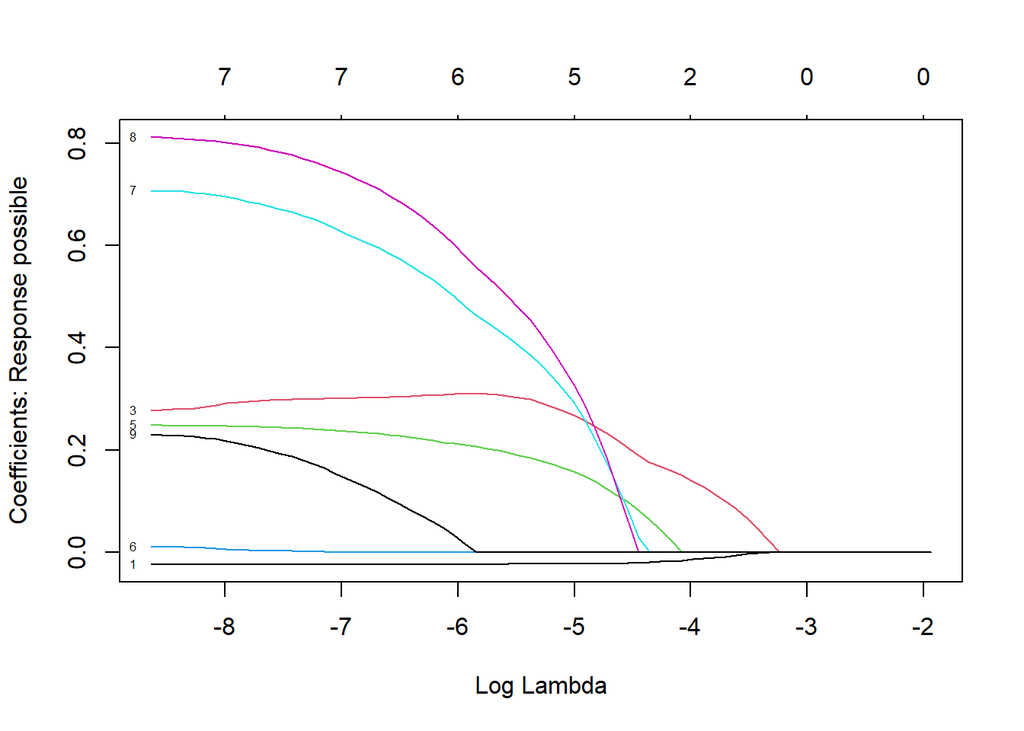

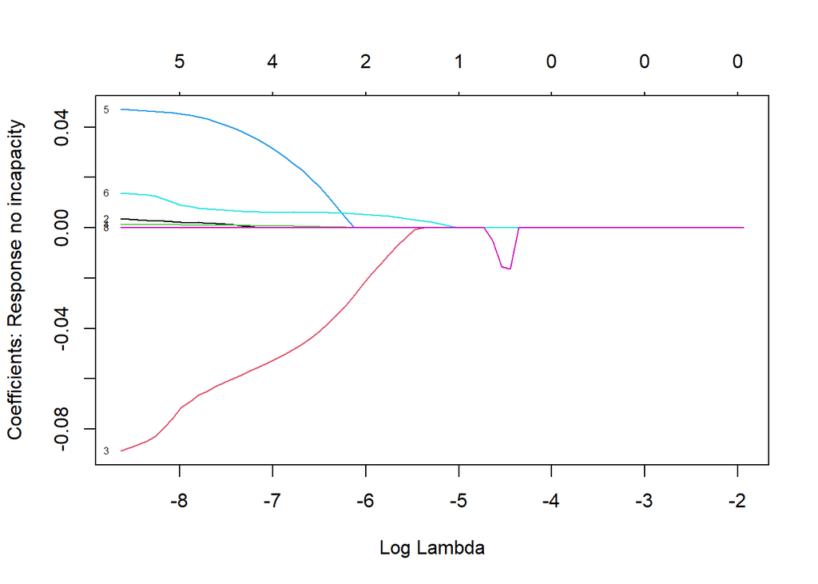

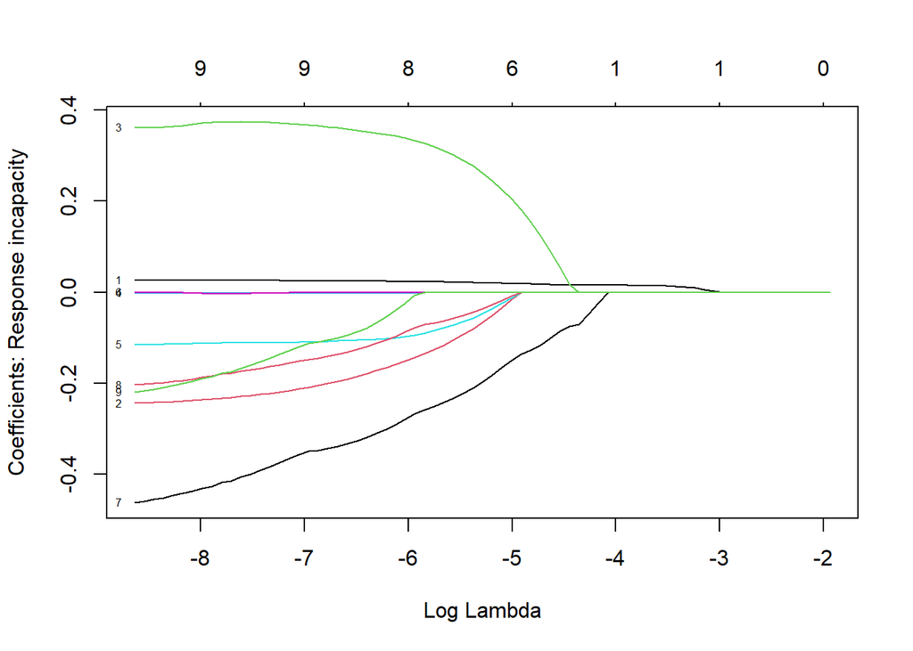

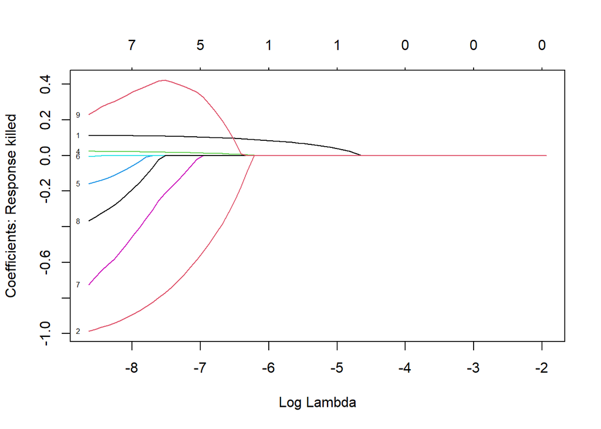

```r
multi.lasso.fit<-cv.glmnet(train.x,train.y,weights=train.data$weight,family='multinomial')
plot(multi.lasso.fit)
```

Let’s take a look at the coefficients:

```r
coef(multi.lasso.fit,s='lambda.min')
```

```
## $none
## 10 x 1 sparse Matrix of class "dgCMatrix"
##                         1
## (Intercept)   3.697344101
## dvcat        -0.069724643
## frontal       0.005646038
## sex          -0.468707056
## ageOFocc     -0.013960192
## occRole       .
## vehage       -0.010607678
## beltedab      1.203742444
## onlyseatbelt  1.313885062
## onlyairbag   -0.237035598
##
## $possible
## 10 x 1 sparse Matrix of class "dgCMatrix"
##                         1
## (Intercept)   1.189708854
## dvcat        -0.024408658
## frontal       .
## sex           0.298712830
## ageOFocc      .
## occRole       0.242947184
## vehage        0.001835175
## beltedab      0.665919972
## onlyseatbelt  0.777215926
## onlyairbag    0.186803083
##
## $`no incapacity`
## 10 x 1 sparse Matrix of class "dgCMatrix"
##                          1
## (Intercept)   0.9670373920
## dvcat         .
## frontal       0.0011714059
## sex          -0.0599481595
## ageOFocc      0.0009553467
## occRole       0.0395608162
## vehage        0.0067376036
## beltedab      .
## onlyseatbelt  .
```

[output cut: 14 more lines]

```
## onlyairbag   -0.153061089
##
## $killed
## 10 x 1 sparse Matrix of class "dgCMatrix"
##                        1
## (Intercept)  -6.21455831
## dvcat         0.10800099
## frontal      -0.73982867
## sex           .
## ageOFocc      0.01796921
## occRole       .
## vehage        .
## beltedab     -0.17735326
## onlyseatbelt  .
## onlyairbag    0.41250063
```

As we can see, the model performs variable selection, selecting a different subset of predictors for each class.

Let’s test the Lasso model:

```r
preds <- factor(predict(multi.lasso.fit,test.x,type='class',s='lambda.min'),levels=c('none','possible','no incapacity','incapacity','killed'))
newx<-data.frame(preds=preds,target=test.y,weights=test.data$weight)
conf.mat<-conf_mat(newx,target,preds,case_weights=weights)
print(summary(conf.mat))
```

```
## # A tibble: 13 × 3
##    .metric              .estimator .estimate
##    <chr>                <chr>          <dbl>
##  1 accuracy             multiclass    0.509
##  2 kap                  multiclass    0.0983
##  3 sens                 macro         0.249
##  4 spec                 macro         0.818
##  5 ppv                  macro         0.475
##  6 npv                  macro         0.854
##  7 mcc                  multiclass    0.132
##  8 j_index              macro         0.0674
##  9 bal_accuracy         macro         0.534
## 10 detection_prevalence macro         0.2
## 11 precision            macro         0.475
## 12 recall               macro         0.249
## 13 f_meas               macro         0.233
```

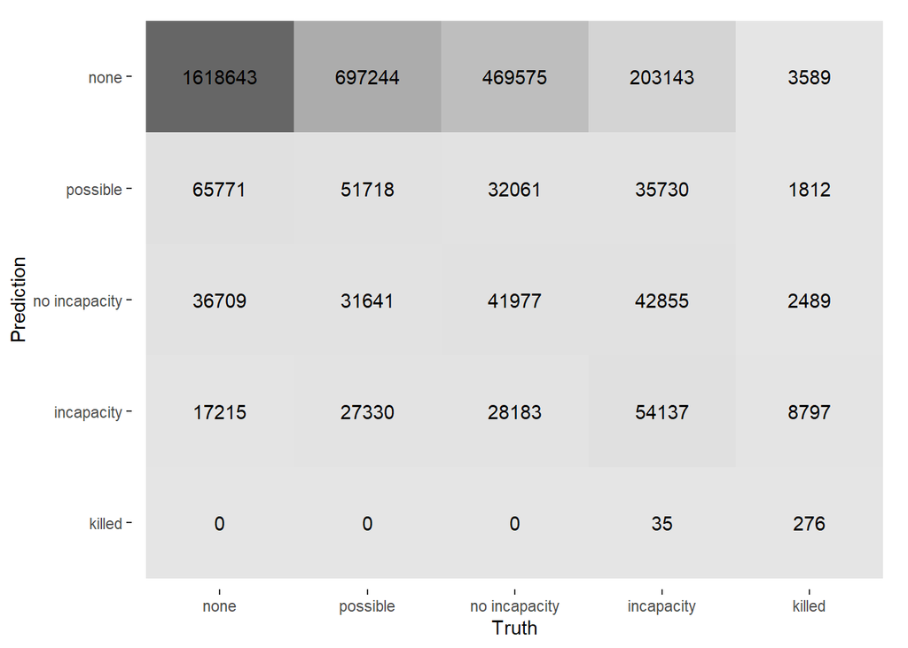

```r
autoplot(conf.mat,type='heatmap')
```

### Full model + interactions

We also fit the model including interactions between predictors:

```r
int.m<-multinom(injSevFactor~(dvcat+sex+frontal)*(onlyseatbelt+onlyairbag+beltedab)+occRole+vehage+ageOFocc,data=train.data,weights=weight,Hess=TRUE)
ev.model(int.m,test.data)
```

```
## # A tibble: 13 × 3
##    .metric              .estimator .estimate
##    <chr>                <chr>          <dbl>
##  1 accuracy             multiclass    0.513
##  2 kap                  multiclass    0.113
##  3 sens                 macro         0.264
##  4 spec                 macro         0.821
##  5 ppv                  macro         0.370
##  6 npv                  macro         0.856
##  7 mcc                  multiclass    0.147
##  8 j_index              macro         0.0850
##  9 bal_accuracy         macro         0.543
## 10 detection_prevalence macro         0.2
## 11 precision            macro         0.370
## 12 recall               macro         0.264
## 13 f_meas               macro         0.256
```

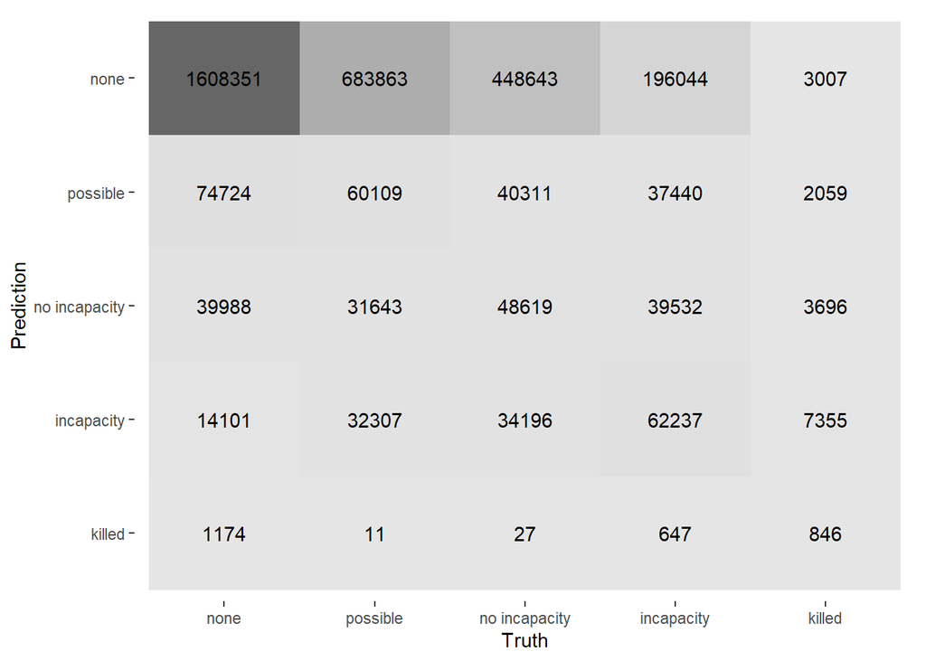

The performance is still bad: we try adding regularization.

### Regularized models

#### Interactions + Lasso regularization

```r
f <- as.formula(injSevFactor~(dvcat+sex+frontal)*(onlyseatbelt+onlyairbag+beltedab)+occRole+vehage+ageOFocc)

train.int.x <- model.matrix(f, train.data)[, -1]
test.int.x<-model.matrix(f,test.data)[,-1]
```

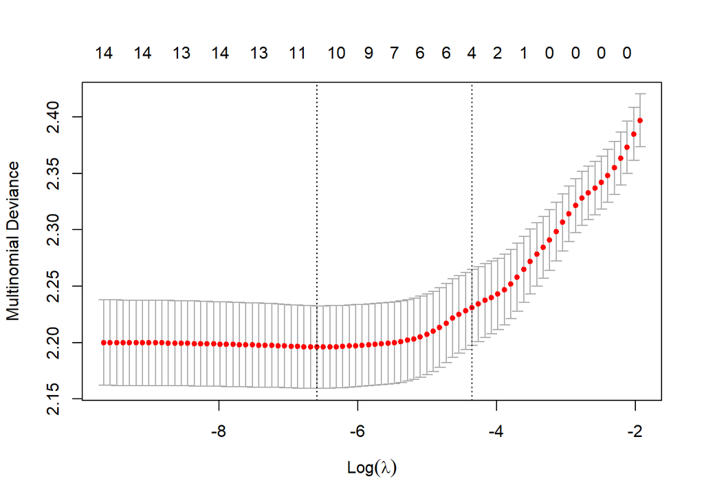

```r
int.lasso.fit<-cv.glmnet(train.int.x,train.y,family='multinomial',weights=train.data$weight)
plot(int.lasso.fit)
```